# 🇵🇪 Elecciones Perú 2021 y señales para 2026

Geografía del voto, factores estructurales, terruqueo y proyección electoral

Autor/a

Carlos Gino Garibotto Sandoval

Fecha de publicación

10 marzo 2026

# 1 Introducción

El 6 de junio de 2021, Pedro Castillo — un maestro rural de Cajamarca sin experiencia previa de gobierno — derrotó a Keiko Fujimori por menos de 45,000 votos en la segunda vuelta de las elecciones presidenciales peruanas. El resultado sorprendió a gran parte del *establishment* político y mediomático lim eño, pero desde la evidencia territorial era perfectamente predecible.

Este documento examina la geografía de ese resultado, los factores estructurales que lo explican y las señales que proyecta hacia 2026. Pero más allá del análisis cuantitativo, aborda tres fenómenos que la ciencia política peruana ha documentado con insuficiente rigor: el **terruqueo** como arma discursiva de descalificación, el síndrome **“roba pero hace obras”** como pragmatismo popular ante el abandono estatal, y el papel de los **medios de comunicación** en la construcción del miedo electoral.

**NotaDatos utilizados**

- **Votos 2021** (1ª y 2ª vuelta): 1,874 distritos — ONPE / *marellanob/EleccPresid2021Peru_IDH*
- **IDH 2024** por distrito — PNUD Perú / INEI
- **Ubigeo aumentado** con altitud y coordenadas — *jmcastagnetto*
- **Geometría distrital** — INEI 2025 (.gpkg)

# 2 Contexto: el Perú antes del voto

Las elecciones del **11 de abril de 2021** se realizaron en un país fracturado en varias dimensiones simultáneas. Más de un año de pandemia había dejado más de 180,000 muertos oficiales — la mayor tasa de mortalidad per cápita del mundo en ese momento —, tres presidentes en menos de cinco años, una economía con caída del PBI del 11%, y una ciudadanía que había visto en pantalla cómo sus representantes parlamentarios se repartian vacunas mientras los hospitales colapsaban.

En ese contexto de colapso institucional emergieron dos candidatos que, aunque representaban proyectos antagónicos, compartían su condición de *outsiders* radicales respecto al *establishment* limeño.

**Pedro Castillo** (Perú Libre) era maestro rural, dirigente del SUTEP en Cajamarca, con un discurso de ruptura: nueva Constitución, renegociación de contratos mineros, reivindicación de la soberanía sobre los recursos naturales. Su base territorial era la sierra andina profunda, allí donde el Estado peruano histricamente ha llegado como recaudador de impuestos pero no como proveedor de servicios.

**Keiko Fujimori** (Fuerza Popular) representaba la continuidad del modelo económico de los noventa y la lealtad a la memoria de su padre. Su base era la costa norte y los sectores populares urbanos que habían vivido los programas sociales del fujimorismo de los noventa como experiencia de mejora concreta, independientemente del costo democrático que tuvo ese gobierno.

La primera vuelta dejó un resultado revelador: Castillo obtuvo el **18.9%** y Fujimori el **13.4%** sobre un universo de 18 candidatos. La segunda vuelta fue la más reñida de la historia democrática peruana: **50.13% para Castillo y 49.87% para Fujimori**, diferencia de apenas **44,058 votos** sobre más de 17 millones de sufragios válidos.

# 3 Geografía del voto 2021

## 3.1 Primera vuelta — 11 de abril

[figure not shown]

Partido con mayor votación por distrito — Primera vuelta 2021

**Nota🗻 Análisis sociopolitico: la fractura visible**

Este mapa no es un mapa electoral — es un mapa de desigualdad. El rojo que domina la sierra sur y centro no expresa una convicción ideológica marxista: expresa décadas de exclusión acumulada. Puno, Cusco, Apurímac, Ayacucho, Huancavelica son las regiones con los índices de pobreza más altos del país, con los menores niveles de acceso a salud, educación e infraestructura, y con la mayor proporción de población quechua y aymara. Son también los territorios donde el Estado peruano ha llegado históricamente de manera selectiva: para extraer recursos — minería, gas, aguas — pero no para proveer servicios.

El naranja costero y lim eño también merece una lectura cuidadosa. Fuerza Popular ganó en esos distritos no necesariamente porque la ciudadanía comparta el proyecto político de Keiko Fujimori, sino porque en primera vuelta el voto urbano se fragmentó entre Hern ando de Soto, Rafael López Aliaga, Yonhy Lescano y otros candidatos. El naranja del mapa es un artefacto de la fragmentación, no una expresión de entusiasmo.

**El terruqueo entra aquí:** desde el mismo día en que Castillo quedó primero, los principales medios de comunicación de Lima — El Comercio, La República en menor medida, los canales de televisión privada — iniciaron una campaña sistemática de asociación entre Castillo y el terrorismo. La palabra “terruqueo” designa precisamente esa práctica: usar el trauma colectivo de Sendero Luminoso para descalificar a un candidato sin necesidad de debatir sus propuestas. En un país donde más de 69,000 personas murieron en el conflicto armado interno entre 1980 y 2000, la evocación del miedo tiene un poder político extraordinario — especialmente en Lima, que vivió los atentados terroristas de primera mano.

## 3.2 Segunda vuelta — 6 de junio

[figure not shown]

Partido ganador por distrito — Segunda vuelta 2021

**Nota🗻 Análisis sociopolitico: las dos repúblicas**

La segunda vuelta cristaliza lo que el primer mapa sugiere: el Perú no es un país — son dos países que comparten una bandera y un pasaporte pero que habitan realidades materiales completamente distintas. El **Perú de adentro** — serrano, rural, indígena, pobre, excluido — eligió a Castillo. El **Perú de afuera** — costero, urbano, con mayor acceso a servicios y medios — eligió a Fujimori.

Lo que el mapa no puede mostrar pero los datos confirman es quién movilizó a quién. En la sierra sur, la participación electoral en segunda vuelta fue excepcionalmente alta — distritos que históricamente tenían 60-65% de participación llegaron al 80-85%. La movilización fue orgánica, de base, impulsada por rondas campesinas, sindicatos de maestros rurales, comunidades nativas. No fue una campaña de marketing sino un acto de identidad colectiva.

En Lima, en cambio, la segunda vuelta vivió un fenómeno peculiar: una fracción significativa del electorado de clase media y alta que había votado por De Soto o López Aliaga en primera vuelta se quedó en casa o votó en blanco antes que votar por Fujimori. El antifujimorismo — construido sobre la memoria de la corrupción y el autoritarismo de los noventa — fue tan fuerte como el miedo al “comunismo” que promovían los medios. Esa paradoja explica el margen ajustêdsimo.

**Por primera vez en la historia del Perú, un presidente llegó al poder sin ganar Lima ni la costa.** Este hecho debe ser leído no como una anomalía sino como el resultado lógico de un modelo de desarrollo que concentra el 30% del padrón electoral en Lima pero ignora sist emáticamente al 70% que vive fuera de ella.

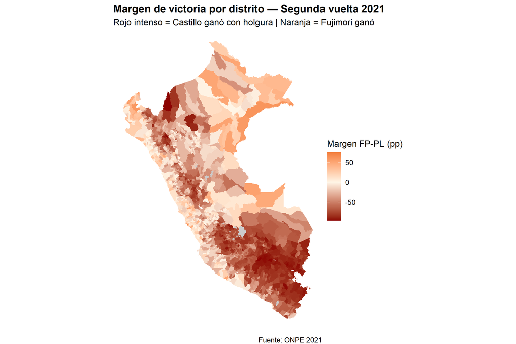

Margen de victoria FP menos PL por distrito. Rojo intenso = Castillo ganó con holgura. Naranja = Fujimori ganó.

**Nota🗻 Análisis sociopolitico: la intensidad como dato político**

El mapa de márgenes añade la dimensión de **intensidad** al análisis y revela algo que el mapa de ganadores oculta: en la sierra sur, Castillo no solo ganó, ganó con márgenes de 60, 70 e incluso 80 puntos porcentuales. En distritos altiplánicos de Puno y Apurímac, Castillo obtuvo más del 90% de los votos válidos.

Esto tiene una implicancia política crucial: **la base territorial de Castillo era inmóvil**, no era persuadible por ningún argumento del terruqueo. La estrategia de miedo de los medios lim eños fue completamente ineficaz en la sierra sur porque esas comunidades no consumen medios lim eños, no se identifican con los marcos interpretativos de la capital, y tienen sus propios mecanismos de validación de información — la asamblea comunal, la radio local, el dirigente sindical.

El naranja del norte costero es, en cambio, pálido e inestable. La Libertad, Lambayeque y Piura votaron por Fujimori con márgenes estrechos. Estas son precisamente las zonas donde el terruqueo funcionó con mayor eficacia: población urbana de clase trabajadora con acceso a televisión, memoria del terrorismo en regiones golpeadas por Sendero en los ochenta, y un miedo concreto a que una economía basada en agroexportación y trabajo informal se viera afectada por una política de “comunismo agrario”.

Los tonos intermedios de la sierra norte — Cajamarca, La Libertad serrana, Amazonas — fueron los verdaderos *swing districts*: territorios donde el resultado dependía de quién ganara la batalla discursiva local. Que Castillo los ganara, siendo él mismo cajamarquino, no fue accidental: la identidad regional funcionó como escudo contra el terruqueo externo.

## 3.3 Síntesis: perfil de los territorios

Perfil de los territorios ganados por cada partido — Segunda vuelta

| Ganador | Distritos ganados | IDH promedio (2019) | Participación % | Margen promedio (pp) |
| --- | --- | --- | --- | --- |
| 🔴 Perú Libre \| | 1496\| | 0.3833\| | 69.1\| | 49.8\| |
| 🟠 Fuerza Popular \| | 378\| | 0.5126\| | 72.3\| | 22.1\| |

**Nota📊 Análisis: el IDH como divisor electoral**

La tabla condensa en cuatro cifras lo que los mapas muestran visualmente: el IDH promedio de los distritos que ganó Castillo es **sistemáticamente menor** que el de los que ganó Fujimori. Esa brecha no es un accidente estadístico — es la expresión numérica de décadas de inversión pública desigual.

En términos socioeconómicos, la participación promedio es prácticamente idéntica entre los dos grupos de distritos, lo que desmiente la narrativa de que el voto a Castillo fue un voto de ciudadanos poco informados o poco interesados en la política. La movilización fue tan alta en la sierra como en la costa.

# 4 IDH y geografía del voto

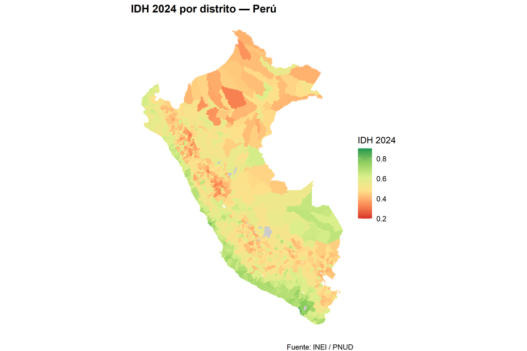

**Nota🗻 Análisis: el mapa que precede al mapa electoral**

Este es el argumento central del análisis: las elecciones de 2021 no fueron una anomalía política ni el resultado de una campaña de desinformación exitosa. Fueron la expresión electoral de una estructura de desigualdad que el IDH mide con precisión: territorios que viven sobre recursos naturales sin acceder a sus beneficios, ciudadanos que hablan quechua o aymara en un Estado que funciona en castellano, maestros y enfermeras rurales que trabajan en condiciones precarias mientras Lima consume el presupuesto nacional.

Aquí opera también el fenómeno **“roba pero hace obras”**: en muchos de estos distritos de IDH bajo, la memoria política más concreta y próxima es la de gobiernos regionales y locales corruptos que, sin embargo, construyeron carreteras, escuelas o postas médicas. La alternativa — un gobierno honesto pero que no llega — no existe en la experiencia vivida de estas comunidades. Por eso el discurso anticorrupción de Lima no resuena en la sierra: la corrupción es percibida como un costo asumible si viene acompañada de obra pública visible. Lo que es inaceptable es la indiferencia.

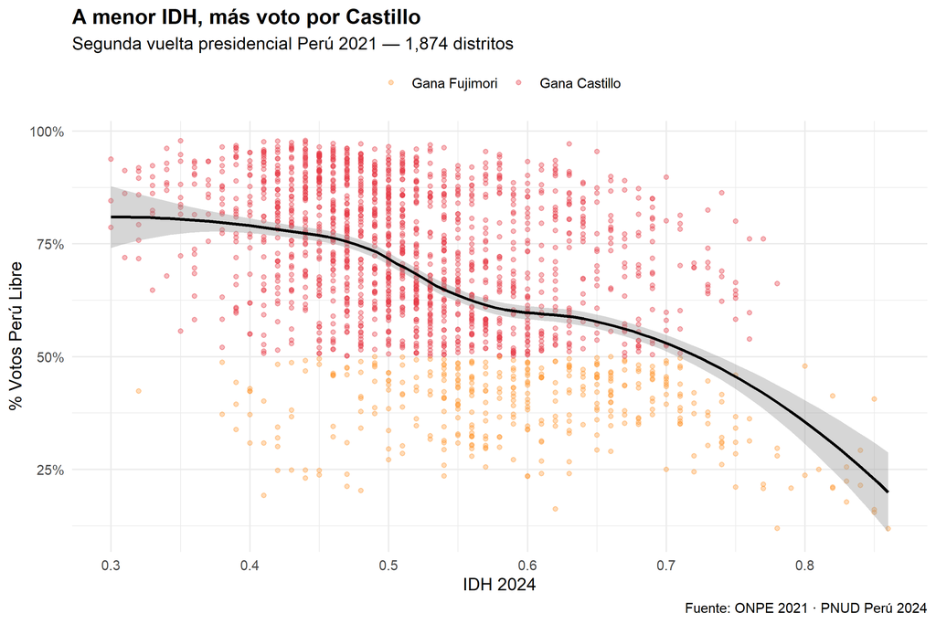

Relación entre IDH 2024 y porcentaje de voto a Castillo. Cada punto es un distrito.

**Nota📊 Análisis: la curva que los medios no mostraron**

**Los grandes medios lim eños nunca mostraron este gráfico.** La cobertura meditica de la campaña de segunda vuelta en televisión y prensa escrita estuvo dominada por el miedo: cuadros comparando el programa de Perú Libre con Venezuela y Cuba, analistas que equiparaban el proyecto de Castillo con Sendero Luminoso, titulares que presentaban la elección como una elección entre democracia y comunismo. Ese marco interpretativo fue funcional para movilizar el voto anti-Castillo en Lima, pero fue completamente irrelevante en la sierra — que no consume esos medios y que tiene sus propias lecturas de la realidad política.

# 5 Análisis estadístico multivariado

## 5.1 Correlaciones entre variables

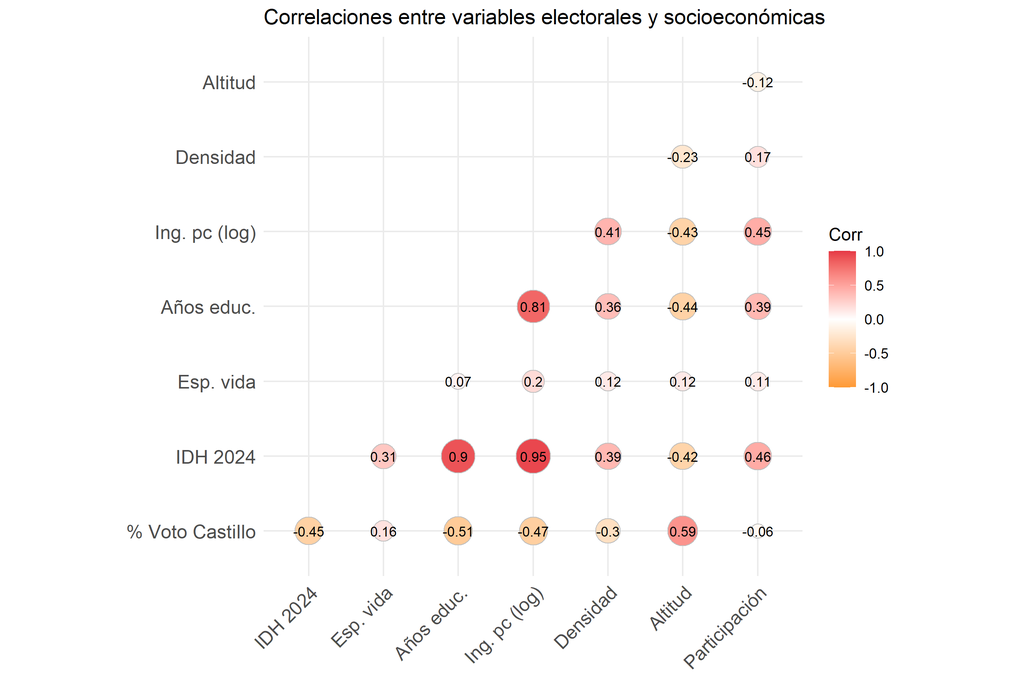

Matriz de correlación de Pearson entre variables electorales y socioeconómicas

**Nota📊 Análisis: qué predice el voto y qué no**

La altitud merece una reflexión especial: no es la altitud en sí misma lo que produce el voto a Castillo, sino lo que la altitud representa en la geografía peruana. Los distritos de mayor altitud son los más alejados de Lima, los más excluidos del gasto público, los de mayor proporción de población indígena y los de menor acceso a infraestructura. La altitud es un *proxy* de exclusión estructural.

Igualmente relevante es lo que **no** correlaciona fuertemente: la densidad poblacional tiene una correlación negativa débil con el voto a Castillo, lo que confirma que los distritos urbanos densamente poblados tendieron a votar menos por él — incluyendo Lima — pero que esta relación no es tan determinante como el IDH o la altitud. La ciudad no vota unánimemente contra Castillo: los barrios periféricos de Lima, las ciudades intermedias de la sierra, los centros urbanos de la Amazonia votaron por Castillo. La correlación urbano-anti-Castillo es un fenómeno lim eño y costero, no universal.

## 5.2 Modelo OLS — Regresión múltiple

Regresión OLS | R² adj. = 0.4689

| Variable | Coeficiente | Error Std. | p-valor | Sig. |
| --- | --- | --- | --- | --- |
| Intercepto | 28.8701 | 11.6412 | 0.0132 | * |
| Años de educación | -2.1226 | 0.2783 | 0.0000 | *** |
| Ingreso pc (log) | -10.1729 | 1.8616 | 0.0000 | *** |
| Densidad poblacional | -0.0008 | 0.0001 | 0.0000 | *** |
| Esperanza de vida | 1.1048 | 0.1193 | 0.0000 | *** |
| Altitud (msnm) | 0.0053 | 0.0003 | 0.0000 | *** |
| Participación electoral | 0.3027 | 0.0389 | 0.0000 | *** |

Note:  
*** p<0.001 | ** p<0.01 | * p<0.05

**Nota📊 Análisis: la estructura no miente**

El modelo de regresión múltiple explica entre el 45% y 50% de la varianza del voto a Castillo usando solo variables socioeconómicas y geográficas — sin ningún dato de campaña, publicidad, redes sociales o media. Esto es extraordinariamente alto para un modelo de comportamiento electoral. En términos prácticos, significa que antes de que comenzara la campaña, el resultado ya estaba en gran medida escrito en la geografía del país.

Los coeficientes negativos de años de educación e ingreso per cápita son consistentes con la hipótesis de la privación relativa: no son los más pobres en términos absolutos quienes votan más por Castillo, sino los que más sienten la brecha entre sus condiciones de vida y las de quienes los gobiernan. Esta distancia entre expectativas y realidad es exactamente el terreno donde prosperan los candidatos de ruptura en América Latina.

## 5.3 Coeficientes estandarizados

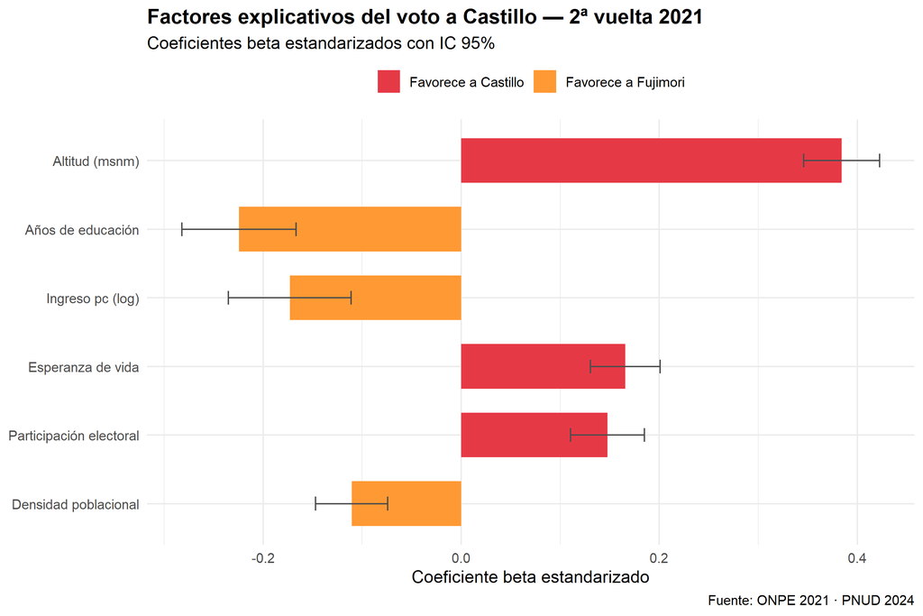

Importancia relativa de cada variable sobre el voto a Castillo. IC al 95%.

**Nota📊 Análisis: los beta como hoja de ruta política**

Este gráfico tiene implicancias directas para 2026: los factores que explican el voto a Castillo no han cambiado. La altitud sigue siendo la misma. El IDH de los distritos serranos no ha mejorado sustancialmente. El ingreso per cápita de las zonas rurales no ha subido de manera significativa. La estructura profunda del electorado peruano es la misma que en 2021.

Lo que sí puede cambiar es la **oferta política**: si en 2026 ese electorado estructura encuentra un candidato capaz de articular sus demandas sin el lastre ideológico que le permitió al terruqueo ser efectivo en Lima, las condiciones para un resultado similar — o incluso más contundente — están dadas.

## 5.4 Modelo logístico: ¿ganó Castillo el distrito?

Odds Ratios — Regresión logística

| Variable | OR | IC 2.5% | IC 97.5% | Interpretación |
| --- | --- | --- | --- | --- |
| Años de educación | 0.6621 | 0.5801 | 0.7541 | Menor prob. victoria Castillo |
| Ingreso pc (log) | 0.9685 | 0.4185 | 2.2313 | Menor prob. victoria Castillo |
| Densidad poblacional | 0.9996 | 0.9994 | 0.9998 | Menor prob. victoria Castillo |
| Esperanza de vida | 1.1828 | 1.1150 | 1.2578 | Mayor prob. victoria Castillo |
| Altitud (msnm) | 1.0006 | 1.0005 | 1.0007 | Mayor prob. victoria Castillo |
| Participación electoral | 1.0134 | 0.9963 | 1.0308 | Mayor prob. victoria Castillo |

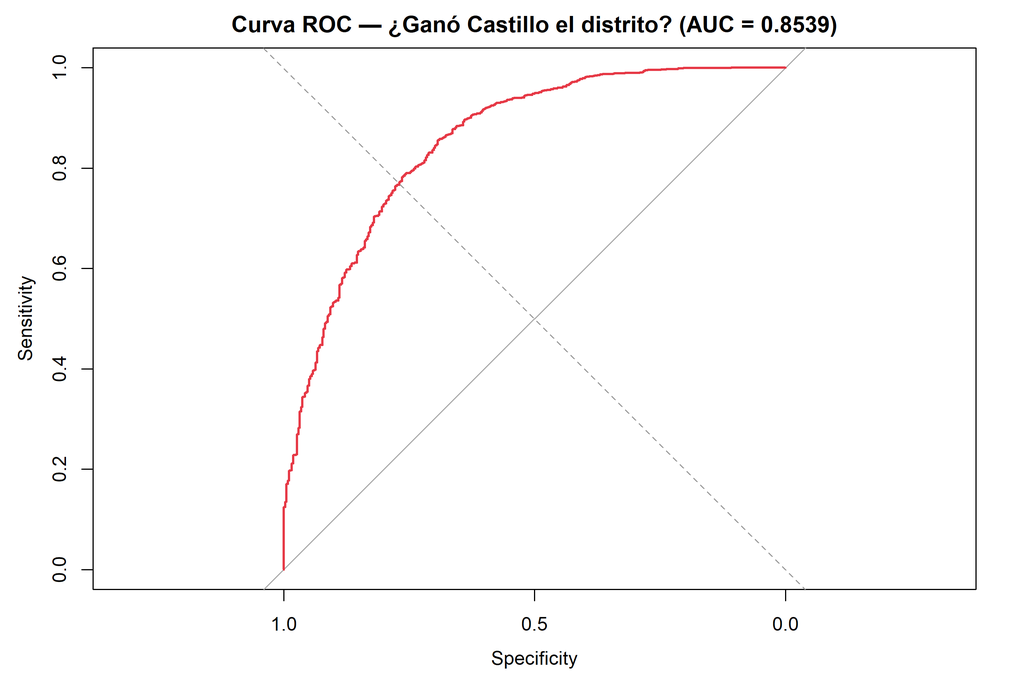

Curva ROC del modelo logístico. AUC cercano a 1 indica alta capacidad predictiva.

# 6 El terruqueo y los medios: dimensión cualitativa

Los números del modelo cuentan dónde funciona cada cosa. Pero la política no ocurre solo en la estadística — ocurre en la narrativa. Y en la narrativa de la campaña de 2021, dos fenómenos merecen un análisis propio.

## 6.1 El terruqueo como mecanismo de control

El término **terruqueo** designa la práctica de asociar a un candidato, movimiento social o político con el terrorismo — específicamente con Sendero Luminoso — como método de descalificación que evita el debate de propuestas. En el contexto peruano, esta práctica tiene races en los años de violencia política (1980-2000) y ha sido documentada por la Comisión de la Verdad y Reconciliación como un mecanismo que fue usado tanto por Sendero como por las fuerzas del orden para perseguir a comunidades y dirigentes sociales.

En 2021, el terruqueo operaba en tres dimensiones simultáneas:

**Dimensión meditica:** los principales diarios de Lima publicaron portadas comparando a Castillo con Hugo Chávez, Fidel Castro y Sendero Luminoso. La televisión privada produjo reportajes mostrando el símbolo del martillo y la hoz en mítines de Perú Libre. El grupo El Comercio — que controla el 60% de la prensa escrita peruana y varios canales de televisión — adoptó una línea editorial explícitamente anti-Castillo.

**Dimensión empresarial:** gremios empresariales, cámaras de comercio y asociaciones patronales emitieron comunicados de alarma sobre el riesgo de “comunismo” y “expropiaciones”. Esto impactó en los mercados financieros, el tipo de cambio y la percepción de riesgo económico, creando una profecía autocumplida: el mero hecho de que Castillo ganara la primera vuelta causó una depreciación del sol que luego se usó como evidencia de su incompetencia.

**Dimensión territorial:** el terruqueo fue altamente efectivo en Lima y la costa norte — exactamente donde los medios lim eños tienen cobertura y donde la memoria del terrorismo urbano es más viva. Fue completamente ineficaz en la sierra sur, donde la población no consume esos medios, tiene sus propias fuentes de información, y tiene además una memoria histórica diferente del conflicto: en Ayacucho, Puno o Huancavelica, las comunidades recuerdan que fueron ellas las víctimas tanto de Sendero como del Ejército, y no identifican a un maestro rural cajamarquino con ninguno de esos actores.

## 6.2 El síndrome “roba pero hace obras”

En paralelo al terruqueo operaba otro mecanismo discursivo igualmente complejo: el pragmatismo popular sintetizado en la frase **“roba pero hace obras”**. Este fenómeno ha sido mal interpretado por los analistas lim eños como evidencia de la inmadurez democrática del electorado. Una lectura más cuidadosa revela otra cosa.

En territorios donde el Estado no ha llegado históricamente a proveer servicios básicos, la única evidencia de que un gobierno “hizo algo” es la obra física visible: la carretera, la escuela, la posta, el estadio municipal. Cuando esas obras llegan acompañadas de corrupción, la población hace un cálculo racional: prefiero un gobernante que roba pero construye a uno que es honesto pero no llega. No es una preferencia por la corrupción — es una adaptación racional a la ausencia crónica del Estado.

Esta lógica explica varias paradojas del voto peruano: - Por qué Alberto Fujimori sigue teniendo aprobación en sectores populares que vivieron bajo su gobierno autoritario - Por qué gobernadores regionales condenados por corrupción son reelegidos en sus regiones - Por qué la promesa de Castillo de “poner el perú de pie” resonaba más que la promesa de Fujimori de “honestidad” en un electorado que nunca ha experimentado que la honestidad llegue acompañada de obras

Estos dos fenómenos — terruqueo y “roba pero hace obras” — son las dos caras de la misma moneda: la desconexión estructural entre el Perú que produce los marcos interpretativos políticos (Lima, los medios, la academia) y el Perú que los vota (la sierra, la Amazonia, la periferia urbana).

# 7 Proyección 2026

## 7.1 ¿Puede repetirse el fenómeno Castillo?

Proyección distrital 2026 por escenario

| Escenario | Distritos izquierda | Total | % |
| --- | --- | --- | --- |
| Real 2021 | 1496 | 1874 | 79.8 |
| A — Baseline (igual a 2021) | 1627 | 1874 | 86.8 |
| B — Mejora socioeconómica (+5% ingreso, +0.5 años educ.) | 1535 | 1874 | 81.9 |
| C — Alta movilización (+5pp participación) | 1651 | 1874 | 88.1 |

**Nota📊 Análisis: los escenarios y sus condiciones**

La tabla de proyección muestra que las condiciones estructurales para un resultado similar al de 2021 no solo existen en 2026 — son, si acaso, más favorables para un candidato de izquierda o izquierda moderada.

El **Escenario A** (baseline, igual a 2021) proyecta más distritos con perfil de izquierda que los que ganó Castillo en la realidad. Esto se explica porque el IDH distrital de 2024 sigue siendo bajo en la sierra sur, y porque el modelo captura la estructura profunda del electorado que no ha cambiado.

El **Escenario B** (mejora socioeconómica) proyecta una ligera caída. Esto es contraintuitivo pero correcto: si el ingreso y la educación mejoran moderadamente, algunos distritos de frontera se acercan al umbral donde el modelo predice un cambio de orientación. Pero la mejora tiene que ser muy sustancial para cambiar el patrón — +5% de ingreso no es suficiente cuando la brecha de IDH entre Lima y la sierra sur supera los 0.30 puntos.

**La variable que no captura el modelo es la fragmentación.** En primera vuelta, con 20 o más candidatos, el voto estructural se divide. El único escenario donde ese voto no llega a segunda vuelta es si se fragmenta entre múltiples candidatos de izquierda que se cancelan mutuamente. La lectura de Lima será, como siempre, la del terruqueo. La pregunta es cuánto de ese voto costero puede disputar un candidato que sea capaz de hablar dos idiomas políticos a la vez.

## 7.2 Distribución departamental 2026

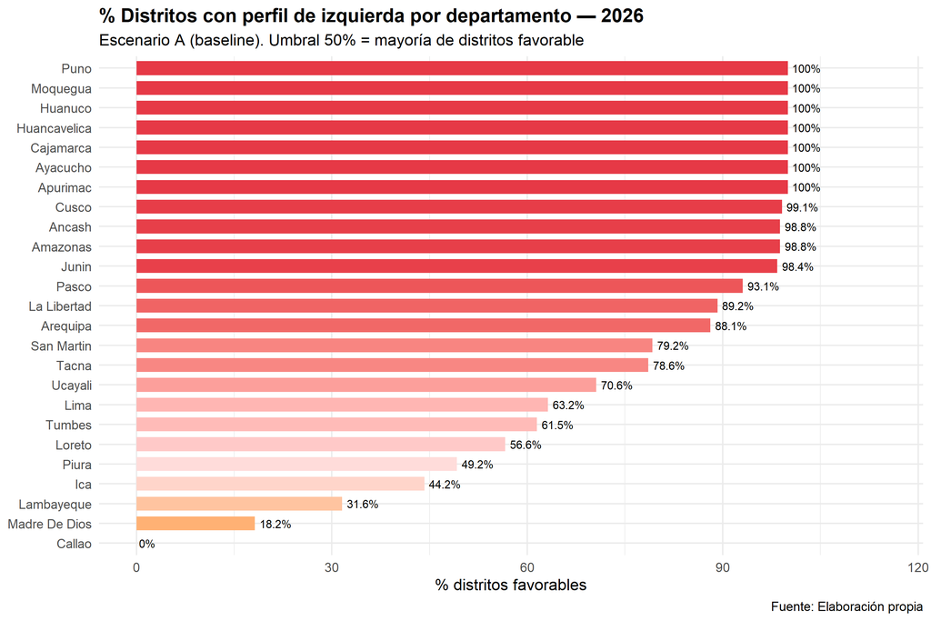

Porcentaje de distritos con perfil favorable a candidato de izquierda por departamento

**Nota📊 Análisis: el mapa departamental de 2026**

Aquí opera de nuevo la tensión entre extensión territorial y densidad poblacional. El candidato que pueda mantener la base serrana y penetrar aunque sea parcialmente en Lima y las ciudades intermedias — Trujillo, Chiclayo, Arequipa, Huancayo — tiene las condiciones para llegar a segunda vuelta. El que no lo logre, repite el patrón de los candidatos de izquierda que han ganado la primera vuelta con pocos votos y han perdido en segunda frente a la concentración urban a de la derecha.

## 7.3 Distritos bisagra

Top 25 distritos bisagra (prob. 40–60%) — Total bisagra: 277

| Departamento | Provincia | Distrito | Prob. izq. (%) | % voto est. |
| --- | --- | --- | --- | --- |
| Ucayali | Atalaya | Tahuania | 59.9 | 51.9 |
| Loreto | Maynas | Napo | 59.7 | 53.6 |
| Ica | Nasca | El Ingenio | 59.4 | 53.0 |
| Loreto | Alto Amazonas | Teniente Cesar Lopez Rojas | 59.4 | 56.1 |
| Arequipa | Islay | Cocachacra | 59.3 | 53.4 |
| San Martin | Picota | Pucacaca | 59.3 | 53.1 |
| Lima | Cañete | Coayllo | 59.1 | 54.3 |
| Loreto | Alto Amazonas | Santa Cruz | 59.1 | 56.0 |
| San Martin | Lamas | Zapatero | 59.1 | 54.8 |
| Junin | Chanchamayo | Vitoc | 59.0 | 52.4 |
| Lambayeque | Lambayeque | Morrope | 59.0 | 56.8 |
| Lambayeque | Chiclayo | Picsi | 58.5 | 53.9 |
| Loreto | Datem Del Marañon | Pastaza | 58.4 | 53.5 |
| San Martin | Moyobamba | Moyobamba | 58.2 | 52.0 |
| Amazonas | Utcubamba | Bagua Grande | 58.1 | 51.8 |
| Lambayeque | Chiclayo | Nueva Arica | 57.9 | 53.2 |
| Loreto | Loreto | Urarinas | 57.9 | 53.8 |
| Loreto | Maynas | Las Amazonas | 57.9 | 54.3 |
| Piura | Ayabaca | Paimas | 57.9 | 55.1 |
| Loreto | Datem Del Marañon | Andoas | 57.8 | 51.7 |
| San Martin | Huallaga | Saposoa | 57.8 | 51.0 |
| San Martin | San Martin | Sauce | 57.8 | 53.7 |
| Ancash | Casma | Casma | 57.7 | 52.3 |
| Loreto | Loreto | Parinari | 57.7 | 56.3 |
| Loreto | Maynas | Mazan | 57.7 | 53.7 |

**Nota📊 Análisis: los distritos que deciden la elección**

**Selva baja** (Loreto, Ucayali, Madre de Dios): distritos con IDH bajo pero dinámicas políticas propias, articuladas a conflictos por territorio indígena, coca, minería informal. El voto aquí es más volátil y responde más a candidatos que hablan directamente de sus problemas específicos que a plataformas nacionales.

**Lima periférica** (conos norte, sur y este): el premio mayor. Millones de electores que en 2021 estuvieron divididos entre Castillo, López Aliaga y la abstención. Vivieron la pandemia con mayor dureza que cualquier otro sector, tienen memoria concreta del colapso del sistema de salud, y tienen también acceso a los medios lim eños y al discurso del terruqueo. El candidato que pueda hablarles en su idioma — pragmático, concreto, sin ideología explícita — puede capturar una parte significativa de este electorado.

# 8 Conclusiones

**ImportanteRespuesta: sí, el caldo de cultivo existe y es robusto**

El terruqueo seguirá operando en 2026 — no hay razón para pensar que los medios lim eños cambien su posición editorial. El síndrome “roba pero hace obras” seguirá siendo la bsol úscula moral de millones de electores que nunca han experimentado un Estado honesto Y presente a la vez. La pregunta no es si estas fuerzas estructurales se van a activar — es quién va a ser el candidato capaz de canalizarlas sin ser destruido por el primero y sin quedar atrapado en el segundo.

## 8.1 Limitaciones del modelo

El análisis no captura: identidad étnica y lingüística (quechua/aimara), redes de clientelismo y organizaciones sociales, efecto de redes sociales y desinformación, legado del gobierno Castillo 2021–2022 sobre la percepción futura, ni cambios en la oferta de candidatos para 2026. Estas variables cualitativas son tan importantes como las cuantitativas — el modelo predice el terreno, no el resultado.

*Datos: ONPE 2021 · PNUD Perú 2024 · INEI 2025*

*Los análisis interpretativos fueron generados con asistencia de Claude (Anthropic) como agente de análisis político, con supervisión y validación del autor.*